# INFSCI 2595 Fall 2023 Homework: 08

#### SOLUTION

The posterior predictive summaries associated with the weak prior are shown below. The figure is consistent with the non-Bayesian predictions we visualized previously.

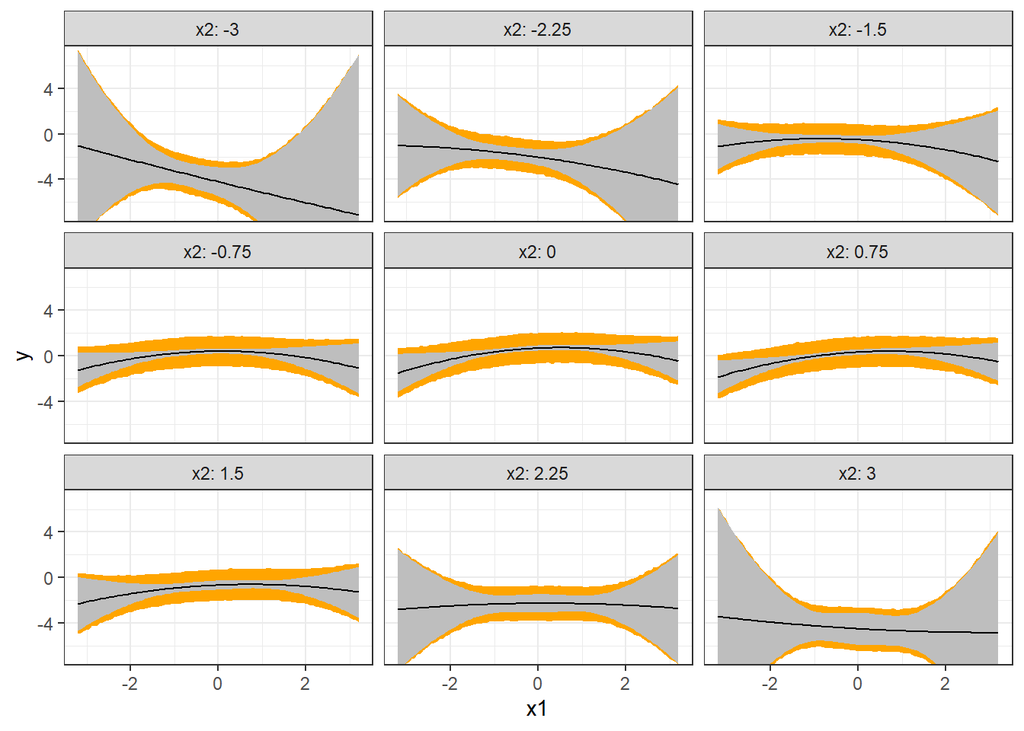

```r
post_pred_summary_viz_03_weak %>%
  left_join(viz_grid %>% tibble::rowid_to_column("pred_id"),
            by = 'pred_id') %>%
  ggplot(mapping = aes(x = x1)) +
  geom_ribbon(mapping = aes(ymin = y_lwr,
                            ymax = y_upr),
              fill = 'orange') +
  geom_ribbon(mapping = aes(ymin = mu_lwr,
                            ymax = mu_upr),
              fill = 'grey') +
  geom_line(mapping = aes(y = mu_avg),
            color = 'black') +
  coord_cartesian(ylim = c(-7, 7)) +
  facet_wrap(~x2, labeller = "label_both") +
  labs(y = 'y') +
  theme_bw()
```

The posterior predictive summaries associated with the strong prior are visualized below. We should not be surprised that the figure below is very close to the previous figure above. We already saw that the weak and strong priors have similar coefficient posteriors for `mod03`.

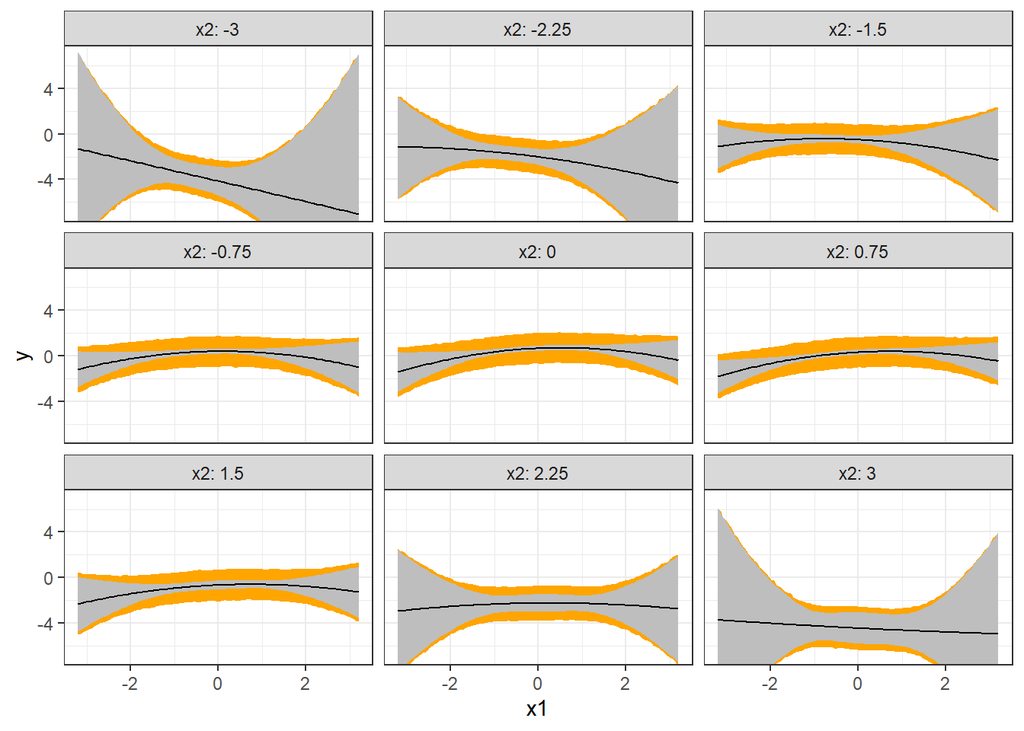

```r
post_pred_summary_viz_03_strong %>%
  left_join(viz_grid %>% tibble::rowid_to_column("pred_id"),
            by = 'pred_id') %>%
  ggplot(mapping = aes(x = x1)) +
  geom_ribbon(mapping = aes(ymin = y_lwr,
                            ymax = y_upr),
              fill = 'orange') +
  geom_ribbon(mapping = aes(ymin = mu_lwr,
                            ymax = mu_upr),
              fill = 'grey') +
  geom_line(mapping = aes(y = mu_avg),
            color = 'black') +
  coord_cartesian(ylim = c(-7, 7)) +
  facet_wrap(~x2, labeller = "label_both") +
  labs(y = 'y') +
  theme_bw()
```

Finally, the posterior predictive summaries for `mod03` based on the very strong prior are shown below. The confidence interval is smaller relative to the prediction interval because the very strong prior restricted the coefficients and thus prevented the trend from matching the observations. This drives up the error and thus increases the size of the prediction interval relative to the confidence interval.

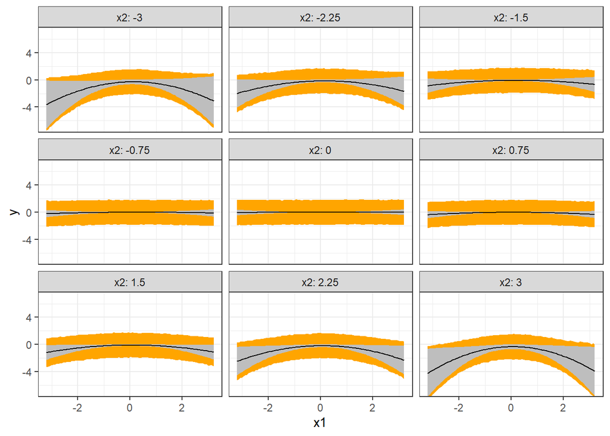

```r
post_pred_summary_viz_03_very_strong %>%
  left_join(viz_grid %>% tibble::rowid_to_column("pred_id"),
            by = 'pred_id') %>%
  ggplot(mapping = aes(x = x1)) +
  geom_ribbon(mapping = aes(ymin = y_lwr,
                            ymax = y_upr),
              fill = 'orange') +
  geom_ribbon(mapping = aes(ymin = mu_lwr,
                            ymax = mu_upr),
              fill = 'grey') +
  geom_line(mapping = aes(y = mu_avg),
            color = 'black') +
  coord_cartesian(ylim = c(-7, 7)) +
  facet_wrap(~x2, labeller = "label_both") +
  labs(y = 'y') +
  theme_bw()
```

You were not required to do this, but we can compile all predictions into a single figure. This way we can directly compare the predictions coming from the models based on the weak, strong, and very strong priors. The posterior predictions associated with the weak and strong priors are quite similar. However, it is clear that the very strong prior, with its very constraining and limiting coefficient range, yields different predictive behavior!

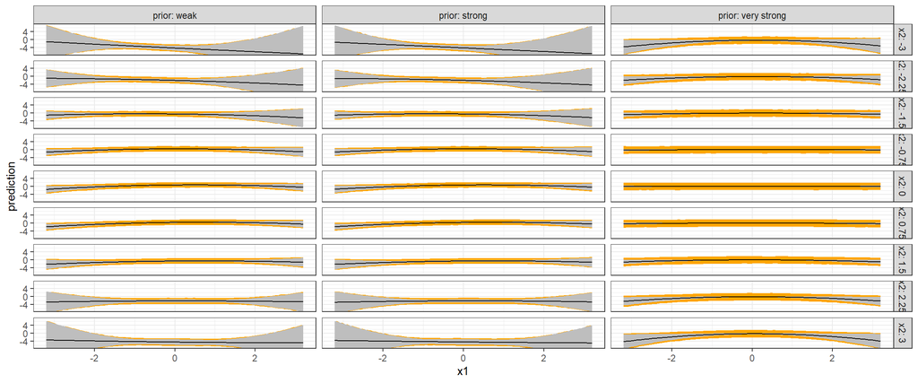

```r
purrr::map2_dfr(list(post_pred_summary_viz_03_weak,
                     post_pred_summary_viz_03_strong,
                     post_pred_summary_viz_03_very_strong),
                c("weak", "strong", "very strong"),
                function(ll, lid){ll %>% mutate(prior = lid)}) %>%
  left_join(viz_grid %>% tibble::rowid_to_column("pred_id"),
            by = 'pred_id') %>%
  mutate(prior = factor(prior,
                        levels = c('weak', 'strong', 'very strong'))) %>%
  ggplot(mapping = aes(x = x1)) +
  geom_ribbon(mapping = aes(ymin = y_lwr,
                            ymax = y_upr,
                            group = interaction(prior, x2)),
              fill = 'orange') +
  geom_ribbon(mapping = aes(ymin = mu_lwr,
                            ymax = mu_upr,
                            group = interaction(prior, x2)),
              fill = 'grey') +
  geom_line(mapping = aes(y = mu_avg,
                          group = interaction(prior, x2)),
            color = 'black') +
  coord_cartesian(ylim = c(-7, 7)) +
  facet_grid(x2 ~ prior, labeller = "label_both") +
  labs(y = 'prediction') +
  theme_bw()
```

### 4e)

In order to make posterior predictions for the model 6 formulation you must create a test design matrix consistent with the training set basis. The code chunk below creates a helper function which extracts the interior and boundary knots of a natural spline associated with the training set for you. The first argument, `J`, is the degrees-of-freedom (DOF) of the spline, the second argument, `train_data`, is the training data set. The third argument `xname` is the name of the variable you are applying the spline to. The `xname` argument **must** be provided as a character string.

```r
make_splines_training_knots <- function(J, train_data, xname)
{
  # extract the input from the training set
  x <- train_data %>% select(all_of(xname)) %>% pull()

  # create the training basis
  train_basis <- splines::ns(x, df = J)

  # extract the knots
  interior_knots <- as.vector(attributes(train_basis)$knots)

  boundary_knots <- as.vector(attributes(train_basis)$Boundary.knots)

  # book keeping
  list(interior_knots = interior_knots,
       boundary_knots = boundary_knots)
}
```

**Create the test design matrix based on the visualization grid, `viz_grid`, using the model 6 formulation. Assign the result to the `X06_test` object. Use the `make_splines_training_knots()` function to get the interior and boundary knots associated with the training set for the `x1` variable to create the test design matrix.**

**Call the `summarize_lm_pred_from_laplace()` function to summarize the posterior predictions from the model 6 formulation for the weak, strong, and very strong prior specifications. Use 5000 posterior samples for each case. Assign the results from the weak prior to `post_pred_summary_viz_06_weak`, the results from the strong prior to `post_pred_summary_viz_06_strong`, and the results from the very strong prior to `post_pred_summary_viz_06_very_strong`.**

*HINT*: The `make_spline_training_knots()` function returns a list! The fields or elements of the list can be accessed via the `$` operator.

#### SOLUTION

The model 6 formulation test design matrix is created below. The knots consistent with the training set are extracted first.

```r
x1_spline_knots <- make_splines_training_knots(12, df, 'x1')

X06_test <- model.matrix( ~ splines::ns(x1, knots = x1_spline_knots$interior_knots, Boundary.knots = x1_spline_knots$boundary_knots) *
                            (x2 + I(x2^2) + I(x2^3) + I(x2^4)),
                          data = viz_grid)
```

The posterior predictive summaries are calculated below for each prior specification.

```r
post_pred_summary_viz_06_weak <- summarize_lm_pred_from_laplace(laplace_06_weak,
                                                                X06_test,
                                                                5000)

post_pred_summary_viz_06_strong <- summarize_lm_pred_from_laplace(laplace_06_strong,
                                                                  X06_test,
                                                                  5000)

post_pred_summary_viz_06_very_strong <- summarize_lm_pred_from_laplace(laplace_06_very_strong,
                                                                       X06_test,
                                                                       5000)
```

### 4f)

You will now visualize the posterior predictions from the model 6 Bayesian models associated with the weak, strong, and very strong priors. The `viz_grid` object is joined to the prediction dataframes assuming you have used the correct variable names!

**Visualize the predicted means, confidence intervals, and prediction intervals in the style of those that you created in Problem 02. The confidence interval bounds are `mu_lwr` and `mu_upr` columns and the prediction interval bounds are the `y_lwr` and `y_upr` columns, respectively. The posterior predicted mean of the mean is `mu_avg`.**

**Pipe the result of the joined dataframe into `ggplot()` and make appropriate aesthetics and layers to visualize the predictions with the `x1` variable mapped to the `x` aesthetic and the `x2` variable used as a facet variable.**

#### SOLUTION

The posterior predictive summaries associated with `mod06` and the weak prior are shown below. The trend and confidence interval have similar behavior to what was previously shown with the non-Bayesian predictions from `mod06`. The confidence interval is not as wide as the non-Bayesian result because the weak prior is still “restrictive” relative to an infinitely diffuse prior! That is why the posterior means for the weak prior are not as extreme as the Maximum Likelihood Estimates (MLEs).

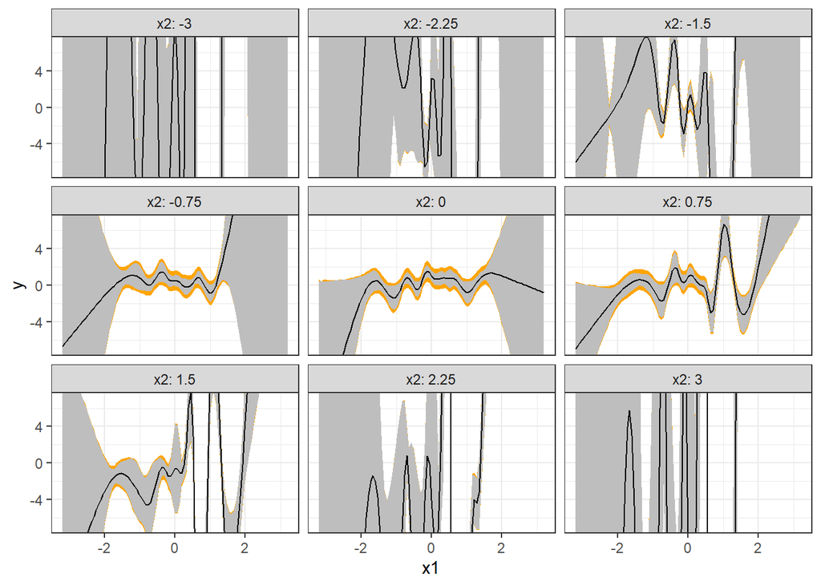

```r
post_pred_summary_viz_06_weak %>%
  left_join(viz_grid %>% tibble::rowid_to_column("pred_id"),
            by = 'pred_id') %>%
  ggplot(mapping = aes(x = x1)) +
  geom_ribbon(mapping = aes(ymin = y_lwr,
                            ymax = y_upr),
              fill = 'orange') +
  geom_ribbon(mapping = aes(ymin = mu_lwr,
                            ymax = mu_upr),
              fill = 'grey') +
  geom_line(mapping = aes(y = mu_avg),
            color = 'black') +
  coord_cartesian(ylim = c(-7, 7)) +
  facet_wrap(~x2, labeller = "label_both") +
  labs(y = 'y') +
  theme_bw()
```

As we saw with the posterior coefficient summary plot, the strong prior pulls the coefficients closer to zero. The easiest way to see the change is to focus on the facets associated with `x2` close to 0. The trend with respect to `x1` has been forced to be closer to a constant because the coefficients are not “allowed” to be such extreme values.

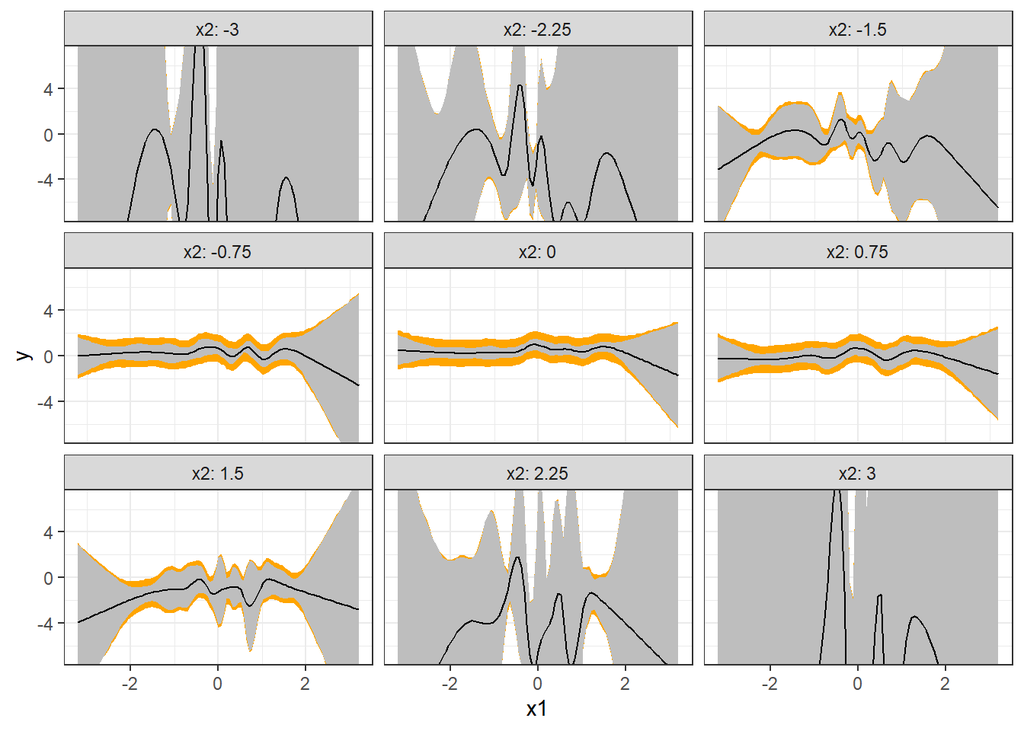

```r
post_pred_summary_viz_06_strong %>%
  left_join(viz_grid %>% tibble::rowid_to_column("pred_id"),
            by = 'pred_id') %>%
  ggplot(mapping = aes(x = x1)) +
  geom_ribbon(mapping = aes(ymin = y_lwr,
                            ymax = y_upr),
              fill = 'orange') +
  geom_ribbon(mapping = aes(ymin = mu_lwr,
                            ymax = mu_upr),
              fill = 'grey') +
  geom_line(mapping = aes(y = mu_avg),
            color = 'black') +
  coord_cartesian(ylim = c(-7, 7)) +
  facet_wrap(~x2, labeller = "label_both") +
  labs(y = 'y') +
  theme_bw()
```

The very strong prior has forced all coefficients to be much closer to zero. The trend with respect `x1` is now essentially negligible. The only remaining influence is `x2` shifting the constant trend with respect to `x1` up or down.

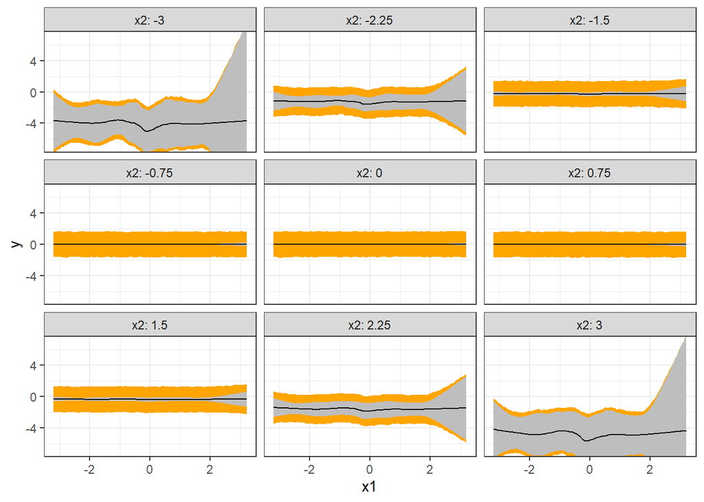

```r
post_pred_summary_viz_06_very_strong %>%
  left_join(viz_grid %>% tibble::rowid_to_column("pred_id"),
            by = 'pred_id') %>%
  ggplot(mapping = aes(x = x1)) +
  geom_ribbon(mapping = aes(ymin = y_lwr,
                            ymax = y_upr),
              fill = 'orange') +
  geom_ribbon(mapping = aes(ymin = mu_lwr,
                            ymax = mu_upr),
              fill = 'grey') +
  geom_line(mapping = aes(y = mu_avg),
            color = 'black') +
  coord_cartesian(ylim = c(-7, 7)) +
  facet_wrap(~x2, labeller = "label_both") +
  labs(y = 'y') +
  theme_bw()
```

Lastly, we can compile the `mod06` posterior predictions into a single figure to make it easier to directly compare the prior’s influence on the predictive trends. As before, you were not required to do this. We have already discussed that `mod06` is quite complex. We see that the strong prior has an impact relative to the weak prior. Limiting the coefficient ranges away from what the likelihood alone prefers helps remove some of the extreme “wiggles” and reduces the overfitting behavior of this complex model. The very strong prior forces the trends with respect to `x1` to nearly “go away” producing nearly flat trends as `x1` changes.

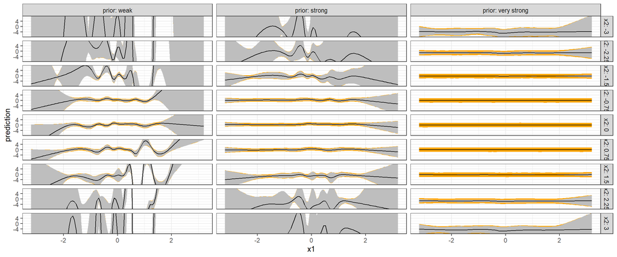

```r
purrr::map2_dfr(list(post_pred_summary_viz_06_weak,
                     post_pred_summary_viz_06_strong,
                     post_pred_summary_viz_06_very_strong),
                c("weak", "strong", "very strong"),
                function(ll, lid){ll %>% mutate(prior = lid)}) %>%
  left_join(viz_grid %>% tibble::rowid_to_column("pred_id"),
            by = 'pred_id') %>%
  mutate(prior = factor(prior,
                        levels = c('weak', 'strong', 'very strong'))) %>%
  ggplot(mapping = aes(x = x1)) +
  geom_ribbon(mapping = aes(ymin = y_lwr,
                            ymax = y_upr,
                            group = interaction(prior, x2)),
              fill = 'orange') +
  geom_ribbon(mapping = aes(ymin = mu_lwr,
                            ymax = mu_upr,
                            group = interaction(prior, x2)),
              fill = 'grey') +
  geom_line(mapping = aes(y = mu_avg,
                          group = interaction(prior, x2)),
            color = 'black') +
  coord_cartesian(ylim = c(-7, 7)) +
  facet_grid(x2 ~ prior, labeller = "label_both") +
  labs(y = 'prediction') +
  theme_bw()
```

### 4g)

**Describe the behavior of the predictions as the prior standard deviation decreased. Are the posterior predictions consistent with the behavior of the posterior coefficients?**

#### SOLUTION

As mentioned in the previous solutions, decreasing the prior standard deviation increases the strength of the prior. The coefficients are pulled closer to the prior mean, which in this case is zero. We are thus preventing the coefficients from taking on very large values, which prevents the model from interpolating the training points. We are forcing the model to *regress* the training data even if the model has a large number of features. This is exactly what we saw with the posterior coefficient summaries because the coefficients were getting pulled closer to zero.

## Problem 05

Now that you have worked with Bayesian models with the prior *regularizing* the coefficients, you will consider non-Bayesian regularization methods. You will work with the `glmnet` package in this problem which takes care of all fitting and visualization for you.

The code chunk below loads in `glmnet` and so you must have `glmnet` installed before running this code chunk. **IMPORANT**: the `eval` flag is set to FALSE below. Once you download `glmnet` set `eval=TRUE`.

```r
library(glmnet)
```

### 5a)

`glmnet` does not work with the formula interface. And so you must create the training design matrix. However, `glmnet` prefers the the intercept column of ones to **not** be included in the design matrix. To support that you must define new design matrices. These matrices will use the same formulation but you must remove the intercept column. This is easy to do with the formula interface and the `model.matrix()` function. Include `- 1` in the formula and `model.matrix()` will not include the intercept. The code chunk below demonstrates removing the intercept column for a model with linear additive features.

```r
model.matrix( y ~ x1 + x2 - 1, data = df) %>% head()
```

```
##           x1         x2
## 1 -0.3092328  0.3087799
## 2  0.6312721 -0.5479198
## 3 -0.6827669  2.1664494
## 4  0.2693056  1.2097037
## 5  0.3725202  0.7854860
## 6  1.2966439 -0.1877231
```

**Create the design matrices for `glmnet` for the model 3 and model 6 formulations. Remove the intercept column for both and assign the results to `X03_glmnet` and `X06_glmnet`.**

#### SOLUTION

The design matrix for model 3 are created below for `glmnet`. As a check the names of the columns are displayed to the screen to reveal that the intercept is not present.

```r
X03_glmnet <- model.matrix(y ~ (x1 + I(x1^2)) * (x2 + I(x2^2)) - 1, data = df)

X03_glmnet %>% colnames()
```

```
## [1] "x1"              "I(x1^2)"         "x2"              "I(x2^2)"
## [5] "x1:x2"           "x1:I(x2^2)"      "I(x1^2):x2"      "I(x1^2):I(x2^2)"
```

The design matrix for model 6 is created below and again the column names are displayed to the screen.

```r
X06_glmnet <- model.matrix(y ~ splines::ns(x1, 12) * (x2 + I(x2^2) + I(x2^3) + I(x2^4)) - 1,
                           data = df)

X06_glmnet %>% colnames()
```

```
##  [1] "splines::ns(x1, 12)1"          "splines::ns(x1, 12)2"
##  [3] "splines::ns(x1, 12)3"          "splines::ns(x1, 12)4"
##  [5] "splines::ns(x1, 12)5"          "splines::ns(x1, 12)6"
##  [7] "splines::ns(x1, 12)7"          "splines::ns(x1, 12)8"
##  [9] "splines::ns(x1, 12)9"          "splines::ns(x1, 12)10"
## [11] "splines::ns(x1, 12)11"         "splines::ns(x1, 12)12"
## [13] "x2"                            "I(x2^2)"
## [15] "I(x2^3)"                       "I(x2^4)"
## [17] "splines::ns(x1, 12)1:x2"       "splines::ns(x1, 12)2:x2"
## [19] "splines::ns(x1, 12)3:x2"       "splines::ns(x1, 12)4:x2"
## [21] "splines::ns(x1, 12)5:x2"       "splines::ns(x1, 12)6:x2"
## [23] "splines::ns(x1, 12)7:x2"       "splines::ns(x1, 12)8:x2"
## [25] "splines::ns(x1, 12)9:x2"       "splines::ns(x1, 12)10:x2"
## [27] "splines::ns(x1, 12)11:x2"      "splines::ns(x1, 12)12:x2"
## [29] "splines::ns(x1, 12)1:I(x2^2)"  "splines::ns(x1, 12)2:I(x2^2)"
```

[output cut: 17 more lines]

### 5b)

By default `glmnet` uses the **lasso** penalty. Fit a Lasso model by calling `glmnet()`. The first argument to `glmnet()` is the design matrix and the second argument is a regular vector for the response.

**Train a Lasso model for the model 3 and model 6 formulations, assign the results to `lasso_03` and `lasso_06`, respectively.**

#### SOLUTION

The `glmnet` models with the default options are fit below.

```r
lasso_03 <- glmnet(X03_glmnet, df$y)

lasso_06 <- glmnet(X06_glmnet, df$y)
```

### 5c)

**Plot the coefficient path for each Lasso model by calling the `plot()` function on the `glmnet` model object. Specify the `xvar` argument to be `'lambda'` in the `plot()` call.**

#### SOLUTION

The coefficient path for model 3 is shown below. We see that the coefficients are larger on the left hand side of the plot (lower penalty strength) while the right hand side of the plot has just 1 remaining feature for a stronger penalty.

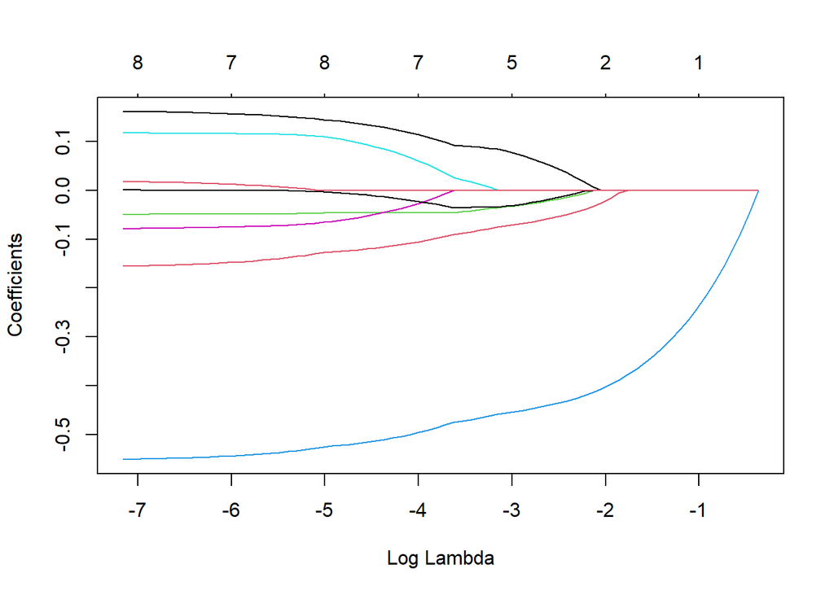

```r
plot(lasso_03, xvar = 'lambda')
```

The effect of the regularization is easier to see with model 6. On the left hand side of the figure, with a smaller penalty there are over 60 non-zero features. Several of those features have coefficients near +/- 5 while another is as large as -10. As the penalty strength increases left-to-right, more features are turned off by the lasso penalty. When the log(lambda) value is -2 there are only 4 non-zero features!

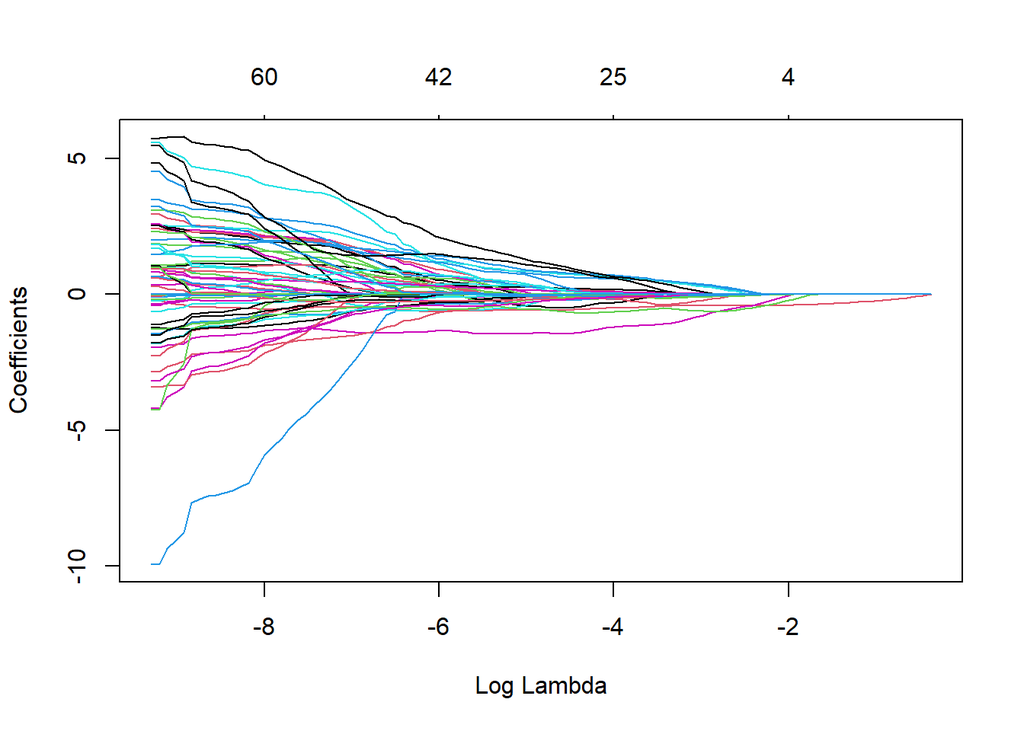

```r
plot(lasso_06, xvar = 'lambda')
```

### 5d)

Now that you have visualized the coefficient path, it’s time to identify the best `'lambda'` value to use! The `cv.glmnet()` function will by default use 10-fold cross-validation to tune `'lambda'`. The first argument to `cv.glmnet()` is the design matrix and the second argument is the regular vector for the response.

**Tune the Lasso regularization strength with cross-validation using the `cv.glmnet()` function for each model formulation. Assign the model 3 result to `lasso_03_cv_tune` and assign the model 6 result to `lasso_06_cv_tune`. Also specify the `alpha` argument to be 1 to make sure the Lasso penalty is applied in the `cv.glmnet()` call.**

*HINT*: The random seed was assigned for you in two separate code chunks below. This will help ensure you can reproduce the cross-validation results.

#### SOLUTION

The model 3 formulation with the lasso penalty is tuned below. The random seed is set so that the cross-validation folds are reproducible. If you do not set the random seed, the cross-validation splits will be different each time the algorithm is run. The `nfolds` argument is also set to 10 even though the default is 10 folds. The `alpha` argument is set to 1 even though that is also the default mixing fraction value.

```r
set.seed(812312)

lasso_03_cv_tune <- cv.glmnet(X03_glmnet, df$y, alpha = 1, nfolds = 10)
```

Likewise, the model 6 lasso penalty is tuned with 10 fold cross-validation below.

```r
set.seed(812312)

lasso_06_cv_tune <- cv.glmnet(X06_glmnet, df$y, alpha = 1, nfolds = 10)
```

### 5e)

**Plot the cross-validation results using the default plot method for each cross-validation result. How many coefficients are remaining after tuning?**

#### SOLUTION

The model 3 lasso cross-validation results are visualized below. The red dot is the cross-validation averaged MSE and the error bars show the +/- 1 standard error around the mean. The vertical dotted line on the left side denotes the lambda value with the minimum averaged MSE. The vertical dotted line on the right side denotes the lamdba value with an averaged MSE within 1 standard error of the best performing value. The top horizontal axis tells us the number of non-zero features. The overall best model has 7 non-zero features, but the one-standard error rule recommends a model that is “within the margin of error” of the best model even though there is just a single feature!!

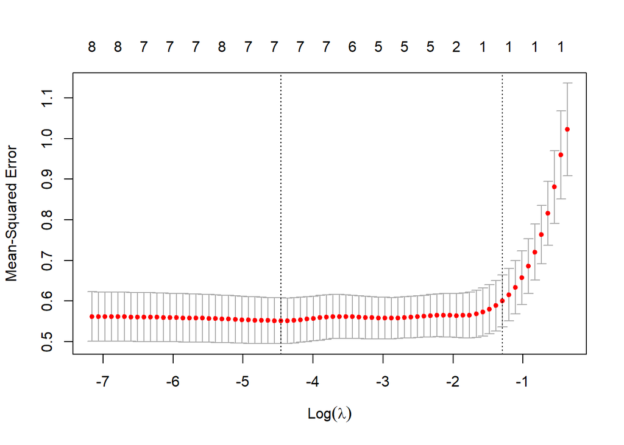

```r
plot(lasso_03_cv_tune)
```

The `cv.glmnet()` returned model object includes fields to help us check more details about the one standard error rule recommended result. You were not required to do this, but it can help us get more details about the lasso regression result. For example, the lambda value associated with the one-standard error rule is (and it’s corresponding log-value):

```r
lasso_03_cv_tune$lambda.1se
```

```
## [1] 0.2732209
```

```r
log(lasso_03_cv_tune$lambda.1se)
```

```
## [1] -1.297475
```

The number of non-zero features can be confirmed by filtering the `nzero` field associated with the `lambda` value equaling the `lambda.1se` value:

```r
lasso_03_cv_tune$nzero[ lasso_03_cv_tune$lambda == lasso_03_cv_tune$lambda.1se ]
```

```
## s10
##   1
```

Likewise, the cross-validation results for the model 6 formulation is shown below. When the penalty strength is low (the left side of the figure) the cross-validation averaged MSE is high! The model with over 60 features is therefore overfitting to the training set! Increasing the penalty strength turns off features which causes the cross-validation performance to improve! The one-standard error rule recommends a lambda value large to have all but a single feature turned off!

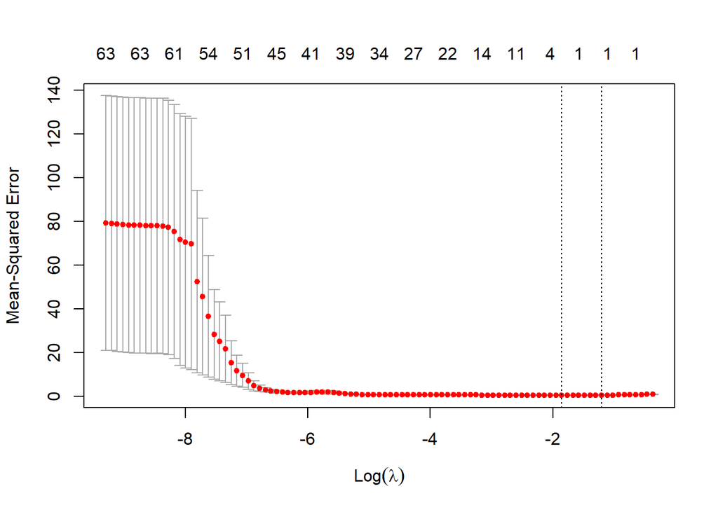

```r
plot(lasso_06_cv_tune)
```

Again, we can check the number of non-zero features as:

```r
lasso_06_cv_tune$nzero[ lasso_06_cv_tune$lambda == lasso_06_cv_tune$lambda.1se ]
```

```
## s9
##  1
```

### 5f)

**Which features have NOT been “turned off” by the Lasso penalty? Use the `coef()` function to display the lasso model cross-validation results to show the tuned penalized regression coefficients for each model.**  
**Are the final tuned models different from each other?**

#### SOLUTION

The coefficients associated with the tuned model 3 lasso model are shown below. The “dot” represents the coefficient (and thus the feature) has been turned off. We see that there is a single non-zero feature (in addition to the intercept). That feature corresponds to the square of `x2`.

```r
coef(lasso_03_cv_tune)
```

```
## 9 x 1 sparse Matrix of class "dgCMatrix"
##                         s1
## (Intercept)      0.3009999
## x1               .
## I(x1^2)          .
## x2               .
## I(x2^2)         -0.3040403
## x1:x2            .
## x1:I(x2^2)       .
## I(x1^2):x2       .
## I(x1^2):I(x2^2)  .
```

We already know that the tuned model 6 has a single non-zero feature based on the one-standard error rule. Displaying the coefficients reveals that the one non-zero feature is also the square of `x2`! Thus, even though model 6 started out with many more features than model 3, lasso has converted the two models into the same model!

```r
coef(lasso_06_cv_tune)
```

```
## 65 x 1 sparse Matrix of class "dgCMatrix"
##                                       s1
## (Intercept)                    0.2818858
## splines::ns(x1, 12)1           .
## splines::ns(x1, 12)2           .
## splines::ns(x1, 12)3           .
## splines::ns(x1, 12)4           .
## splines::ns(x1, 12)5           .
## splines::ns(x1, 12)6           .
## splines::ns(x1, 12)7           .
## splines::ns(x1, 12)8           .
## splines::ns(x1, 12)9           .
## splines::ns(x1, 12)10          .
## splines::ns(x1, 12)11          .
## splines::ns(x1, 12)12          .
## x2                             .
## I(x2^2)                       -0.2847331
## I(x2^3)                        .
## I(x2^4)                        .
## splines::ns(x1, 12)1:x2        .
## splines::ns(x1, 12)2:x2        .
## splines::ns(x1, 12)3:x2        .
## splines::ns(x1, 12)4:x2        .
## splines::ns(x1, 12)5:x2        .
## splines::ns(x1, 12)6:x2        .
## splines::ns(x1, 12)7:x2        .
## splines::ns(x1, 12)8:x2        .
## splines::ns(x1, 12)9:x2        .
## splines::ns(x1, 12)10:x2       .
## splines::ns(x1, 12)11:x2       .
## splines::ns(x1, 12)12:x2       .
## splines::ns(x1, 12)1:I(x2^2)   .
## splines::ns(x1, 12)2:I(x2^2)   .
## splines::ns(x1, 12)3:I(x2^2)   .
## splines::ns(x1, 12)4:I(x2^2)   .
## splines::ns(x1, 12)5:I(x2^2)   .
## splines::ns(x1, 12)6:I(x2^2)   .
## splines::ns(x1, 12)7:I(x2^2)   .
## splines::ns(x1, 12)8:I(x2^2)   .
## splines::ns(x1, 12)9:I(x2^2)   .
```

[output cut: 12 more lines]

```
## splines::ns(x1, 12)10:I(x2^3)  .
## splines::ns(x1, 12)11:I(x2^3)  .
## splines::ns(x1, 12)12:I(x2^3)  .
## splines::ns(x1, 12)1:I(x2^4)   .
## splines::ns(x1, 12)2:I(x2^4)   .
## splines::ns(x1, 12)3:I(x2^4)   .
## splines::ns(x1, 12)4:I(x2^4)   .
## splines::ns(x1, 12)5:I(x2^4)   .
## splines::ns(x1, 12)6:I(x2^4)   .
## splines::ns(x1, 12)7:I(x2^4)   .
## splines::ns(x1, 12)8:I(x2^4)   .
## splines::ns(x1, 12)9:I(x2^4)   .
## splines::ns(x1, 12)10:I(x2^4)  .
## splines::ns(x1, 12)11:I(x2^4)  .
## splines::ns(x1, 12)12:I(x2^4)  .
```